# Week 5: Visualization in Python

## Example gallery

In the previous sections, we focused on the sns.scatterplot() function as an illustrative example.

However, there are many other Seaborn plotting functions.

The following standalone chunks of code are included as an example gallery.

The repeated import statements are included intentionally so that these codes could be copied and re-tooled in your own projects.

**The examples below are just a small subset of what Seaborn can do.**

- For more examples see the following link
- https://seaborn.pydata.org/examples/index.html

**IMPORTANT NOTE:**

- In the examples below, we are using the Seaborn default values.
- If we were planning to use these plots in a publication or project then we would need to do further customization to make them professionally acceptable.

```
<class 'seaborn.axisgrid.FacetGrid'>
```

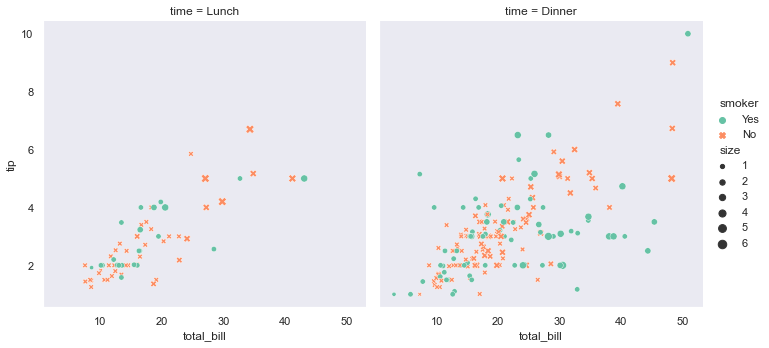

```python
import matplotlib.pyplot as plt
import seaborn  as sns

# LOAD AN EXAMPLE DATASET
df = sns.load_dataset("tips")
#print(df)

# RELPLOT
# This function provides access to several different
# axes-level functions that show the relationship between
# two variables with semantic mappings of subsets.
# The kind parameter selects the underlying axes-level
# function to use:
my_plot=sns.relplot(
    data=df,
    x="total_bill",
    y="tip",
    col="time",
    hue="smoker",
    style="smoker",
    size="size",
)

print(type(my_plot))
plt.show()
```

```
<class 'seaborn.axisgrid.FacetGrid'>
```

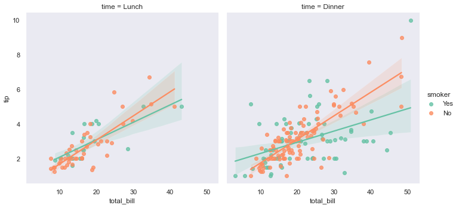

```python
# LINEAR MODEL PLOT (lmplot --> Plot data and regression model fits across a FacetGrid)
sns.lmplot(
    data=df,
    x="total_bill",
    y="tip",
    col="time",
    hue="smoker")
print(type(my_plot))
plt.show()
```

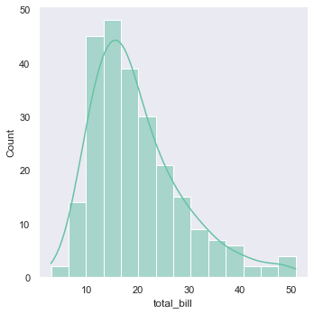

```python
# DISTRIBUTION PLOT-1
sns.displot(
    data=df,
    x="total_bill",
    kde=True
    )
plt.show()
```

The "kde" option, stands for "kernel density estimation".

KDE is a smoothing method used for estimating a continuous probability density distribution from a discrete histogram.

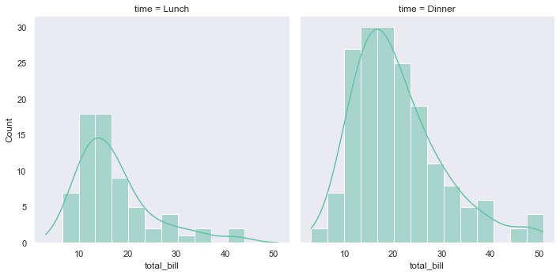

```python
# DISTRIBUTION PLOT-2
sns.displot(
    data=df,
    x="total_bill",
    col="time",
    kde=True
    )
plt.show()
```

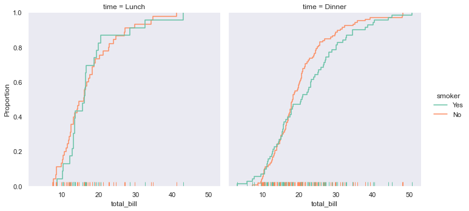

```python
# CUMULATIVE DISTRIBUTION FUNCTION (CDF)

# Notice that we switch from a histogram (default) to a CDF using displot's kind="ecdf" option.
# Also, notice that we can introduce a rug plot, which shows each datapoint, projected on the X axis, using the "rug=True" option

sns.displot(
    data=df,
    kind="ecdf",
    x="total_bill",
    col="time",
    hue="smoker",
    rug=True
)
plt.show()
```

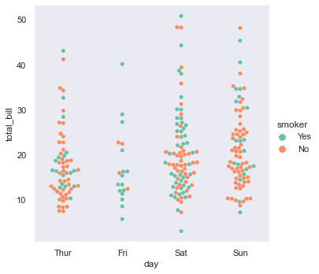

```python
# SWARM PLOT-1
sns.catplot(
    data=df,
    kind="swarm",
    x="day",
    y="total_bill",
    hue="smoker")
plt.show()
```

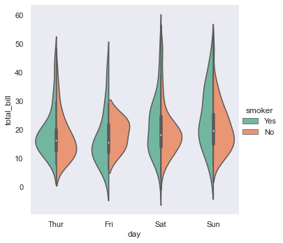

```python
# VIOLIN PLOT
sns.catplot(
    data=df,
    kind="violin",
    x="day",
    y="total_bill",
    hue="smoker",
    split=True
)
plt.show()
```

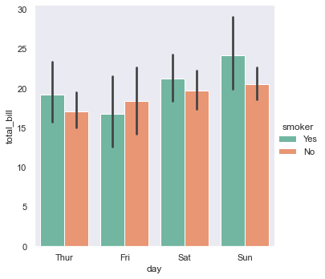

```python
# BAR CHART
sns.catplot(
    data=df,
    kind="bar",
    x="day",
    y="total_bill",
    hue="smoker")
plt.show()
```

# References

Content from this tutorial was taken from several sources cited below:

- https://matplotlib.org/stable/tutorials/introductory/pyplot.html#sphx-glr-tutorials-introductory-pyplot-py
- https://towardsdatascience.com/what-are-the-plt-and-ax-in-matplotlib-exactly-d2cf4bf164a9